[figure not shown]

# Where?

### Where Do Police Detain People?

### Map Details

- These maps display all police detainments between 2012-2014 and 2016-2017.
- Each point represents one stop.
- Points do not represent exact locations of each stop
- density of the dots represent the density of detainments in a geographic area.
- To help guide your eyes, detainments that include Search and Frisk are circled in red
- Turn on and off underlying population characteristics through the box on the right

### Detainments 2012 - 2014 & 2016 - 2017

[interactive chart not shown]

### Detainments by Beat

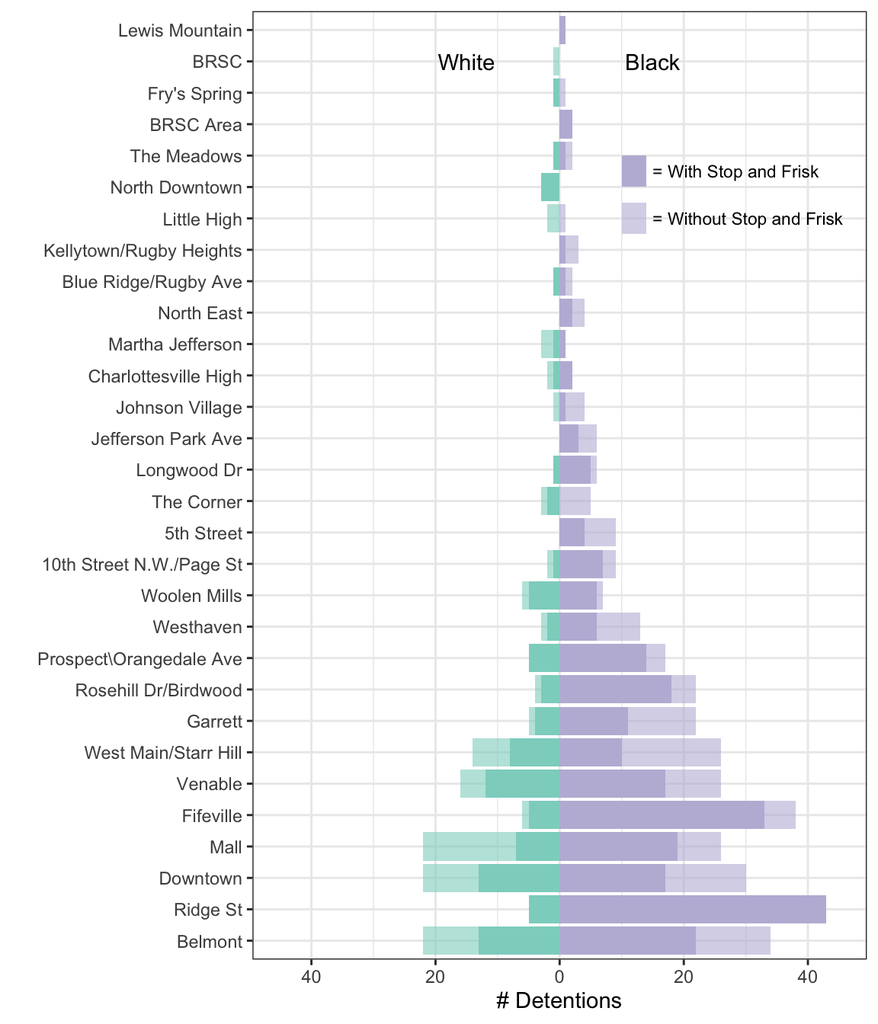

### Changes Over Time

Trends:

- Greater dispersion of stop and frisk throughout the city during the 2017
- Noticeable decrease of stop and frisk in *some* predominantly black neighborhoods such as the Rose Hill nieghborhood.
- Stop and frisk of black individuals in areas with predominantly student housing increased, specifically in the Grady, Rugby Road, and Emmet Street Areas in addition to the areas south of west main by the train tracks and Jefferson Park Avenue.
- Stop and Frisk increased significantly, particularly for black individuals, in the Prospect/Orangedale Ave area.

### 2012-2014

[interactive chart not shown]

### 2016-2017

[interactive chart not shown]

### Over Policing & Exclusive Spaces

This is where I think we could tie in some narrative that you are collecting, Jordy, to analyze some specific spaces that may have more fraught histories. I gave an example with the Mall.

### Ridge Street & Prospect-OrangeDale Neighborhoods

[interactive chart not shown]

### Martha Jefferson & Locust Grove Neighborhoods

[interactive chart not shown]

### Downtown

[interactive chart not shown]

### This needs to be prettier

The Downtown Mall is a public space for free use by Charlottesville residents.

- In the periods of 2012 -2014 and 2016-2017, 26 Black individuals were detained by police
- 22 White individuals were detained in the same period.
- 73% of Black individuals stopped (19 individuals) were also searched and frisked
- 31% (7) of White individuals were also searched and frisked.